# Sentiment Analysis

Siva Bulusu

13/12/2019

Johnnie Walker is selected as a brand for analysis. Johnnie Walker is a brand of Scotch whisky (now owned by Diageo) that originated in the Scottish town of Kilmarnock, East Ayrshire. The brand was first established by grocer John Walker. It is the most widely distributed brand of blended Scotch whisky in the world, sold in almost every country.

The csv file (JW_Tweets.csv) downloaded in the specified path is attached in portal. CSV file contains 1308 tweets for period 5-May-2019 to 14-May-2019. The twees are downloaded from twitter as a csv file with name “JW_Tweets.csv”. This file is used for analysis.

## Sentiment Analysis

Load required libraries

```r
library(stringr)
library(tm)
```

```r
library(stringi)
library(ggplot2)
library(gridExtra)
library(grid)
library(RColorBrewer)
library(wordcloud)
library(topicmodels)
library(syuzhet)
```

Set working directory and verify.

```r
setwd("D:/SivaBulusu/SentimentAnalysis")
getwd()
```

```
## [1] "D:/SivaBulusu/SentimentAnalysis"
```

Read tweets and do required conversions for columns.

```r
#Read data
tweets.df <- read.csv("JW_Tweets.csv")
str(tweets.df)
```

```
## 'data.frame':    1308 obs. of  17 variables:
##  $ X            : int  1 2 3 4 5 6 7 8 9 10 ...
##  $ text         : Factor w/ 733 levels "'There’s room for a lot more whisky attractions in the city'. Edinburgh's @ScotchWhiskyExp is about to be joine"| __truncated__,..: 269 447 446 558 558 122 121 20 448 490 ...
##  $ favorited    : logi  FALSE FALSE FALSE FALSE FALSE FALSE ...
##  $ favoriteCount: int  0 0 0 0 0 0 0 2 0 0 ...
##  $ replyToSN    : Factor w/ 170 levels "_dwey01","_impcrium",..: NA NA NA NA NA 111 109 1 NA NA ...
##  $ created      : Factor w/ 1305 levels "2019-05-05 11:00:42",..: 1305 1304 1303 1302 1301 1300 1299 1298 1297 1296 ...
##  $ truncated    : logi  FALSE FALSE TRUE FALSE FALSE FALSE ...
##  $ replyToSID   : num  NA NA NA NA NA ...
##  $ id           : num  1.13e+18 1.13e+18 1.13e+18 1.13e+18 1.13e+18 ...
##  $ replyToUID   : num  NA NA NA NA NA ...
##  $ statusSource : Factor w/ 56 levels "<a href=\"http://alexboboc.com\" rel=\"nofollow\">CocktailsBot</a>",..: 15 13 13 36 14 14 13 14 24 13 ...
##  $ screenName   : Factor w/ 1148 levels "__Wlyrics","_azequiella",..: 368 984 658 390 1025 46 824 929 743 190 ...
##  $ retweetCount : int  0 0 0 530 530 0 0 0 0 3 ...
##  $ isRetweet    : logi  FALSE FALSE FALSE TRUE TRUE FALSE ...
##  $ retweeted    : logi  FALSE FALSE FALSE FALSE FALSE FALSE ...
##  $ longitude    : num  NA NA NA NA NA NA NA NA NA NA ...
##  $ latitude     : num  NA NA NA NA NA NA NA NA NA NA ...
```

```r
#Convert char date to correct date format
lct <- Sys.getlocale("LC_TIME");
Sys.setlocale("LC_TIME", "C")
```

```
## [1] "C"
```

```r
tweets.df$created <- as.Date(tweets.df$created, format= "%Y-%m-%d")
str(tweets.df)
```

```
## 'data.frame':    1308 obs. of  17 variables:
##  $ X            : int  1 2 3 4 5 6 7 8 9 10 ...
##  $ text         : Factor w/ 733 levels "'There’s room for a lot more whisky attractions in the city'. Edinburgh's @ScotchWhiskyExp is about to be joine"| __truncated__,..: 269 447 446 558 558 122 121 20 448 490 ...
##  $ favorited    : logi  FALSE FALSE FALSE FALSE FALSE FALSE ...
##  $ favoriteCount: int  0 0 0 0 0 0 0 2 0 0 ...
##  $ replyToSN    : Factor w/ 170 levels "_dwey01","_impcrium",..: NA NA NA NA NA 111 109 1 NA NA ...
##  $ created      : Date, format: "2019-05-14" "2019-05-14" ...
##  $ truncated    : logi  FALSE FALSE TRUE FALSE FALSE FALSE ...
##  $ replyToSID   : num  NA NA NA NA NA ...
##  $ id           : num  1.13e+18 1.13e+18 1.13e+18 1.13e+18 1.13e+18 ...
##  $ replyToUID   : num  NA NA NA NA NA ...
##  $ statusSource : Factor w/ 56 levels "<a href=\"http://alexboboc.com\" rel=\"nofollow\">CocktailsBot</a>",..: 15 13 13 36 14 14 13 14 24 13 ...
##  $ screenName   : Factor w/ 1148 levels "__Wlyrics","_azequiella",..: 368 984 658 390 1025 46 824 929 743 190 ...
##  $ retweetCount : int  0 0 0 530 530 0 0 0 0 3 ...
##  $ isRetweet    : logi  FALSE FALSE FALSE TRUE TRUE FALSE ...
##  $ retweeted    : logi  FALSE FALSE FALSE FALSE FALSE FALSE ...
##  $ longitude    : num  NA NA NA NA NA NA NA NA NA NA ...
##  $ latitude     : num  NA NA NA NA NA NA NA NA NA NA ...
```

```r
Sys.setlocale("LC_TIME", lct)
```

```
## [1] "English_United Kingdom.1252"
```

```r
#Convert text column in to character
tweets.df$text <- as.character(tweets.df$text)
str(tweets.df)
```

```
## 'data.frame':    1308 obs. of  17 variables:
##  $ X            : int  1 2 3 4 5 6 7 8 9 10 ...
##  $ text         : chr  "Feeling some Johnnie Walker... Blue or Black?" "On a bettrr note, Johnnie White Walker is an actual vibe enuh." "Omgoodness I want to eat everything right now! Teriyaki chicken from Canton. Salsa from Sal's. Hamburger/fries "| __truncated__ "RT @JohnnieWalkerUS: Make sure …
##  $ favorited    : logi  FALSE FALSE FALSE FALSE FALSE FALSE ...
##  $ favoriteCount: int  0 0 0 0 0 0 0 2 0 0 ...
##  $ replyToSN    : Factor w/ 170 levels "_dwey01","_impcrium",..: NA NA NA NA NA 111 109 1 NA NA ...
##  $ created      : Date, format: "2019-05-14" "2019-05-14" ...
##  $ truncated    : logi  FALSE FALSE TRUE FALSE FALSE FALSE ...
##  $ replyToSID   : num  NA NA NA NA NA ...
##  $ id           : num  1.13e+18 1.13e+18 1.13e+18 1.13e+18 1.13e+18 ...
##  $ replyToUID   : num  NA NA NA NA NA ...
##  $ statusSource : Factor w/ 56 levels "<a href=\"http://alexboboc.com\" rel=\"nofollow\">CocktailsBot</a>",..: 15 13 13 36 14 14 13 14 24 13 ...
##  $ screenName   : Factor w/ 1148 levels "__Wlyrics","_azequiella",..: 368 984 658 390 1025 46 824 929 743 190 ...
##  $ retweetCount : int  0 0 0 530 530 0 0 0 0 3 ...
##  $ isRetweet    : logi  FALSE FALSE FALSE TRUE TRUE FALSE ...
##  $ retweeted    : logi  FALSE FALSE FALSE FALSE FALSE FALSE ...
##  $ longitude    : num  NA NA NA NA NA NA NA NA NA NA ...
##  $ latitude     : num  NA NA NA NA NA NA NA NA NA NA ...
```

```r
View(tweets.df)
```

Clean the tweets in ‘text’ & ‘statussource’ columns.

```r
#Clean the tweets in text column
clean_tweets=tweets.df$text

#Convert the tweets in to lower case
clean_tweets = tolower(clean_tweets)

#Remove retweet entities
clean_tweets = gsub('RT @', '', clean_tweets)
clean_tweets = gsub('(RT|via)((?:\\b\\W*@\\w+)+)', '', clean_tweets)

#Remove at people
clean_tweets = gsub('@\\w+', '', clean_tweets)

#Remove punctuation
clean_tweets = gsub('[[:punct:]]', '', clean_tweets)

#Remove numbers
clean_tweets = gsub('[[:digit:]]', '', clean_tweets)

#Remove html links
clean_tweets = gsub('http\\w+', '', clean_tweets)

#Remove unnecessary spaces
clean_tweets = gsub('[ \t]{2,}', '', clean_tweets)
clean_tweets = gsub('^\\s+|\\s+$', '', clean_tweets)

#Remove emojis or special characters
clean_tweets = gsub('<.*>', '', enc2native(clean_tweets))

#Remove unnecessary spaces
clean_tweets <- str_replace_all(clean_tweets," "," ")

#Remove URLs
#clean_tweets <- str_replace_all(clean_tweets, "http://t.co/[a-z,A-Z,0-9]*{8}","")

#Remove retweet header, there is only one
clean_tweets <- str_replace(clean_tweets,"RT @[a-z,A-Z]*: ","")

#Remove hashtags
clean_tweets <- str_replace_all(clean_tweets,"#[a-z,A-Z]*","")

#Remove references to other screennames
clean_tweets <- str_replace_all(clean_tweets,"@[a-z,A-Z]*","")

#Replace johnnie walker by single word
clean_tweets = gsub('johnnie walker', 'johnniewalker', clean_tweets)
clean_tweets = gsub('johnniewalker', '', clean_tweets)

#Replace white walker by single word
clean_tweets = gsub('white walker', 'whitewalker', clean_tweets)

#Push back the cleaned text to text column
tweets.df$text= clean_tweets
View(tweets.df)

#Clean the tweets in statusSource column
clean_tweets=tweets.df$statusSource
#clean_tweets = gsub('<.*>', '', enc2native(clean_tweets))
clean_tweets = gsub('<.*?>', '', clean_tweets)

clean_tweets = gsub('Twitter', '', clean_tweets)
clean_tweets = gsub('for', '', clean_tweets)
#Push back the cleaned text to statusSource column
tweets.df$statusSource= clean_tweets

#View data frame
View(tweets.df)
```

All that are not required and give trouble for analysis like URLs, extra spaces, stop words, etc. are removed using ‘gsub’ which replaces specified string with provided string. The text is converted in to lower case for uniformity. Johnnie Walker is removed as it is not required to count the term for which we are doing all the analysis.

Build corpus for text mining.

```r
#Create document corpus with tweet text
myCorpus<- Corpus(VectorSource(tweets.df$text))
myCorpus1<- Corpus(VectorSource(tweets.df$statusSource))
```

Do some more cleaning on the corpus and take a copy of corpus.

```r
#Convert to Lowercase
myCorpus <- tm_map(myCorpus, content_transformer(stri_trans_tolower))
#Remove the links (URLs)
removeURL <- function(x) gsub("http[^[:space:]]*", "", x)
myCorpus <- tm_map(myCorpus, content_transformer(removeURL))
#Remove the @ (usernames)
removeUsername <- function(x) gsub("@[^[:space:]]*", "", x)
myCorpus <- tm_map(myCorpus, content_transformer(removeUsername))
#Remove anything except the english language and space
removeNumPunct <- function(x) gsub("[^[:alpha:][:space:]]*", "", x)
myCorpus <- tm_map(myCorpus, content_transformer(removeNumPunct))
#Remove Stopwords
myStopWords<- c((stopwords('english')),c("rt", "use", "used", "via", "amp","djokernole","realhughjackman","theborisbecker"))
myCorpus<- tm_map(myCorpus,removeWords , myStopWords)
#Remove Single letter words
removeSingle <- function(x) gsub(" . ", " ", x)
myCorpus <- tm_map(myCorpus, content_transformer(removeSingle))
#Remove Extra Whitespaces
myCorpus<- tm_map(myCorpus, stripWhitespace)
#keep a copy of Corpus created
myCorpusCopy<- myCorpus
myCorpus1Copy<- myCorpus1
```

All that are not required and give trouble for analysis like URLs, extra spaces, stop words, etc. are removed from corpus using ‘tm_map’ which has many text cleaning functions. The text in corpus is converted in to lower case for uniformity.

Create term document matrix using corpus built on ‘text’ & ‘statussource’ columns.

```r
#Creating a term document matrix for text column corpus
tdm<- TermDocumentMatrix(myCorpus, control= list(wordLengths= c(1, Inf)))
tdm
```

```
## <<TermDocumentMatrix (terms: 2232, documents: 1308)>>
## Non-/sparse entries: 10929/2908527
## Sparsity           : 100%
## Maximal term length: 42
## Weighting          : term frequency (tf)
```

```r
#Creating a term document matrix for statusSource column corpus
tdm1<- TermDocumentMatrix(myCorpus1, control= list(wordLengths= c(1, Inf)))
tdm1
```

```
## <<TermDocumentMatrix (terms: 83, documents: 1308)>>
## Non-/sparse entries: 1623/106941
## Sparsity           : 99%
## Maximal term length: 18
## Weighting          : term frequency (tf)
```

Two objects for TDM are built for analysis using ‘text’ & ‘statussource’ columns. TDM built using text column will be used for analyzing the tweets content posted. TDM built using the statussource column will be used for understanding the medium through which people using Johnnie Walkers are posting tweets.

Find frequently used words with minimum frequencies of 10,25,55,85.

```r
#Find the terms used most frequently in text column
(freq.terms <- findFreqTerms(tdm, lowfreq = 10))
```

```
##   [1] "black"           "blue"            "johnnie"         "whitewalker"
##   [5] "everything"      "now"             "bottle"          "freezer"
##   [9] "rtmake"          "sure"            "watchpartyready" "youre"
##  [13] "got"             "im"              "open"            "game"
##  [17] "whisky"          "coming"          "end"             "finally"
##  [21] "winter"          "uf"              "dont"            "whiskey"
##  [25] "like"            "cocktail"        "icy"             "night"
##  [29] "draw"            "entered"         "r"               "rtcongrats"
##  [33] "well"            "win"             "youve"           "new"
##  [37] "season"          "bar"             "s"               "store"
##  [41] "elevate"         "experience"      "viewing"         "available"
##  [45] "big"             "visitor"         "enjoy"           "go"
##  [49] "will"            "d"               "drink"           "best"
##  [53] "day"             "ready"           "today"           "distillery"
##  [57] "edition"         "last"            "limited"         "never"
```

[output cut: 32 more lines]

```r
term.freq <- rowSums(as.matrix(tdm))
term.freq <- subset(term.freq, term.freq > 10)
df <- data.frame(term = names(term.freq), freq= term.freq)
View(df)

#Find the terms used most frequently in text column
(freq.terms <- findFreqTerms(tdm, lowfreq = 25))
```

```
##  [1] "black"           "johnnie"         "whitewalker"     "bottle"
##  [5] "freezer"         "rtmake"          "sure"            "watchpartyready"
##  [9] "youre"           "got"             "game"            "whisky"
## [13] "coming"          "uf"              "whiskey"         "like"
## [17] "cocktail"        "night"           "new"             "season"
## [21] "s"               "experience"      "visitor"         "enjoy"
## [25] "will"            "drink"           "day"             "edition"
## [29] "last"            "series"          "green"           "thrones"
## [33] "get"             "label"           "even"            "one"
## [37] "house"           "show"            "door"            "fruity"
## [41] "friends"         "edinburgh"       "interview"       "sea"
## [45] "given"           "plans"           "may"             "cocktails"
## [49] "time"            "giving"          "mixing"          "rtwinter"
## [53] "radio"           "hour"            "joh"             "long"
## [57] "xtcs"            "part"            "depth"           "rtnew"
## [61] "tomorrow"        "uhere"           "uu"              "withtalking"
## [65] "players"         "special"         "album"           "half"
## [69] "itll"            "rtbbc"           "simple"          "crafted"
## [73] "gabe"            "orta"            "rthold"          "using"
```

```r
term.freq <- rowSums(as.matrix(tdm))
term.freq <- subset(term.freq, term.freq > 25)
df1 <- data.frame(term = names(term.freq), freq= term.freq)
View(df1)

#Find the terms used most frequently in text column
(freq.terms <- findFreqTerms(tdm, lowfreq = 55))
```

```
##  [1] "black"           "whitewalker"     "bottle"          "freezer"
##  [5] "rtmake"          "sure"            "watchpartyready" "youre"
##  [9] "whisky"          "cocktail"        "new"             "experience"
## [13] "will"            "label"           "door"            "fruity"
## [17] "edinburgh"       "sea"             "part"            "simple"
## [21] "crafted"         "gabe"            "orta"            "rthold"
## [25] "using"
```

```r
term.freq <- rowSums(as.matrix(tdm))
term.freq <- subset(term.freq, term.freq > 55)
df2 <- data.frame(term = names(term.freq), freq= term.freq)
View(df2)

#Find the terms used most frequently in text column
(freq.terms <- findFreqTerms(tdm, lowfreq = 85))
```

```
##  [1] "black"           "whitewalker"     "bottle"          "freezer"
##  [5] "rtmake"          "sure"            "watchpartyready" "youre"
##  [9] "whisky"          "cocktail"        "new"             "experience"
```

```r
term.freq <- rowSums(as.matrix(tdm))
term.freq <- subset(term.freq, term.freq > 85)
df3 <- data.frame(term = names(term.freq), freq= term.freq)
View(df3)
```

Words like white walker, cocktail, experience, fruity, crafted, friends, watchpartyready, special, enjoy, great are found very frequently. White Walker is new product being released as limited edition. So, tweets show that people are talking more about it. Also, the words like cocktail, great, experience and watchpartyready show that people have positive opinion on this brand and use it for celebrating at parties.

Plot the graph for frequent terms.

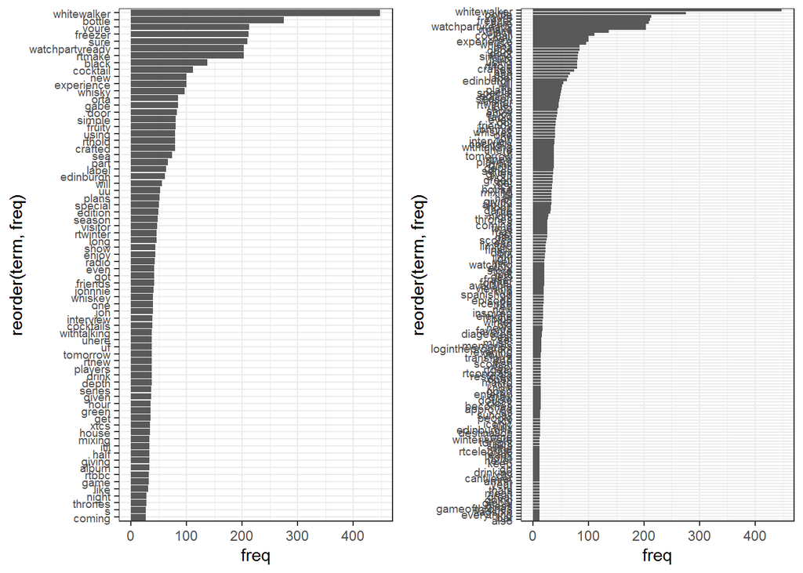

```r
#Plot the graph of frequent terms
p1=ggplot(df1, aes(reorder(term, freq),freq)) + theme_bw() + geom_bar(stat = "identity")  + coord_flip() +labs(list(title="@10", x="Terms", y="Term Counts")) + theme(axis.text.y = element_text(size=7))


p2=ggplot(df, aes(reorder(term, freq),freq)) + theme_bw() + geom_bar(stat = "identity")  + coord_flip() +labs(list(title="@25", x="Terms", y="Term Counts"))+
  theme(axis.text.y = element_text(size=7))


p3=ggplot(df2, aes(reorder(term, freq),freq)) + theme_bw() + geom_bar(stat = "identity")  + coord_flip() +labs(list(title="@55", x="Terms", y="Term Counts"))

p4=ggplot(df3, aes(reorder(term, freq),freq)) + theme_bw() + geom_bar(stat = "identity")  + coord_flip() +labs(list(title="@85", x="Terms", y="Term Counts"))

#Plot the graph of frequent terms
grid.arrange(p1,p2,ncol=2)
```

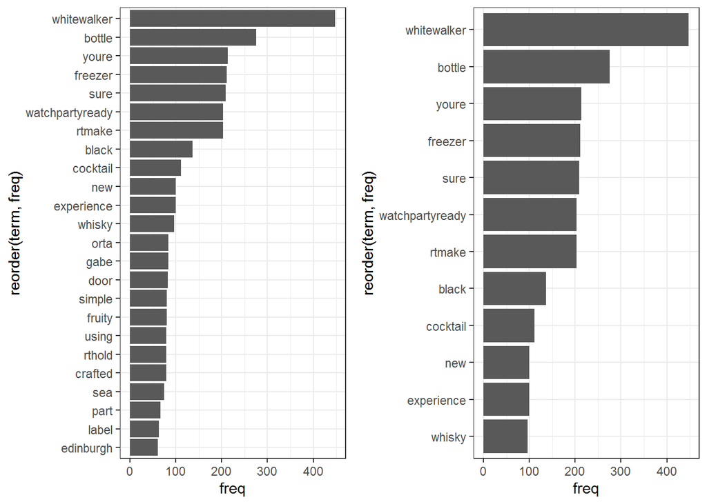

```r
grid.arrange(p3,p4,ncol=2)
```

White walker, bottle, freezer, watchpartyready, make, cock tail, experience, whisky are some words with most frequency.

Create word cloud on text column related tdm and observe.

[figure not shown]

```r
word.freq <-sort(rowSums(as.matrix(tdm)), decreasing= F)
pal<- brewer.pal(8, "Dark2")
wordcloud(words = names(word.freq), freq = word.freq, min.freq = 2, random.order = F, colors = pal, max.words = 150)
```

Words like Bottle, freezer, sure, make, experience, watchpartyready, cocktail, fruity, whisky are observed dominantly in the word cloud. This indicates party mood and celebration.

Find most frequently used in statussource column and create word cloud.

```r
#Find frequent words used most frequently in statusSource column
(freq.terms <- findFreqTerms(tdm1, lowfreq = 25))
```

```
## [1] "android"   "app"       "web"       "iphone"    "client"    "ipad"
## [7] "hootsuite" "inc."
```

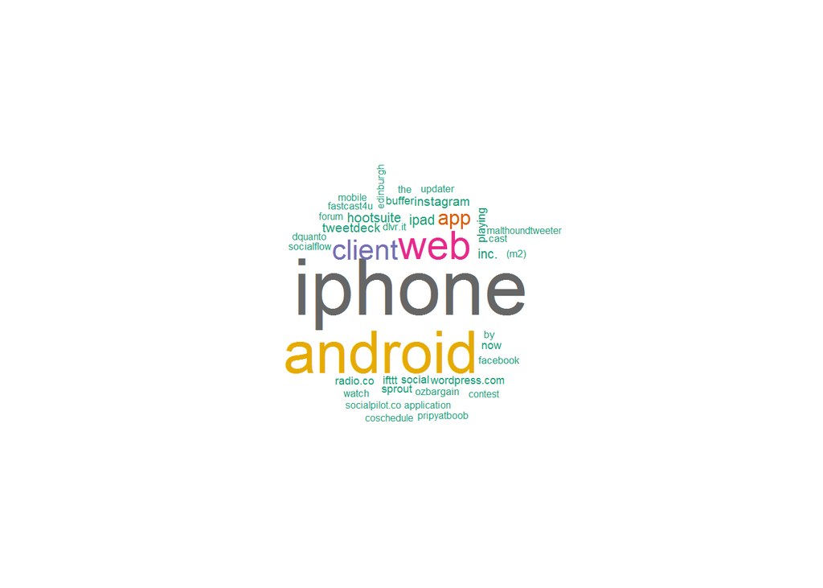

```r
term.freq1 <- rowSums(as.matrix(tdm1))
term.freq1 <- subset(term.freq1, term.freq1 > 25)
df11 <- data.frame(term = names(term.freq1), freq= term.freq1)
View(df11)

#Calculate frequency of words, sort it by frequency and create the Wordcloud
word.freq1 <-sort(rowSums(as.matrix(tdm1)), decreasing= F)
pal<- brewer.pal(8, "Dark2")
wordcloud(words = names(word.freq1), freq = word.freq1, min.freq = 2, random.order = F, colors = pal, max.words = 150)
```

Words iphone & android are very dominant in the word cloud followed by web. This shows that most of the people celebrating with Johnnie Walker’s products are using mobiles to tweet. Few are using web platforms. Most of the mobile tweets are from Apple devices like iphone and ipad. This is obvious as Johnnie Walker’s products are costly and preferred by people who can spend more (generally people who can spend more use Apple devices).

Perform topic modelling on the tweets. Get 5 topics with 7 terms in each topic.

```r
#Topic Modelling to identify latent/hidden topics using LDA technique
dtm <- as.DocumentTermMatrix(tdm)
rowTotals <- apply(dtm , 1, sum)
NullDocs <- dtm[rowTotals==0, ]
dtm   <- dtm[rowTotals> 0, ]

if (length(NullDocs$dimnames$Docs) > 0) {
  tweets.df <- tweets.df[-as.numeric(NullDocs$dimnames$Docs),]
}

#Find 5 topics with first 7 terms of every topic
lda <- LDA(dtm, k = 5) # find 5 topics
term <- terms(lda, 7) # first 7 terms of every topic
(term <- apply(term, MARGIN = 2, paste, collapse = ", "))
```

```
##                                                              Topic 1
##              "whisky, plans, will, edition, house, got, whitewalker"
##                                                              Topic 2
##                     "black, long, radio, players, sea, series, hour"
##                                                              Topic 3
##                    "new, black, experience, uu, season, enjoy, show"
##                                                              Topic 4
##            "whitewalker, cocktail, gabe, orta, door, fruity, simple"
##                                                              Topic 5
## "bottle, whitewalker, youre, freezer, sure, rtmake, watchpartyready"
```

Mostly the topics have words white walker, enjoy, cock tail, freezer, bottle, fruity. This indicates celebration and party mood.

Perform sentiment analysis on tweets in the text column.

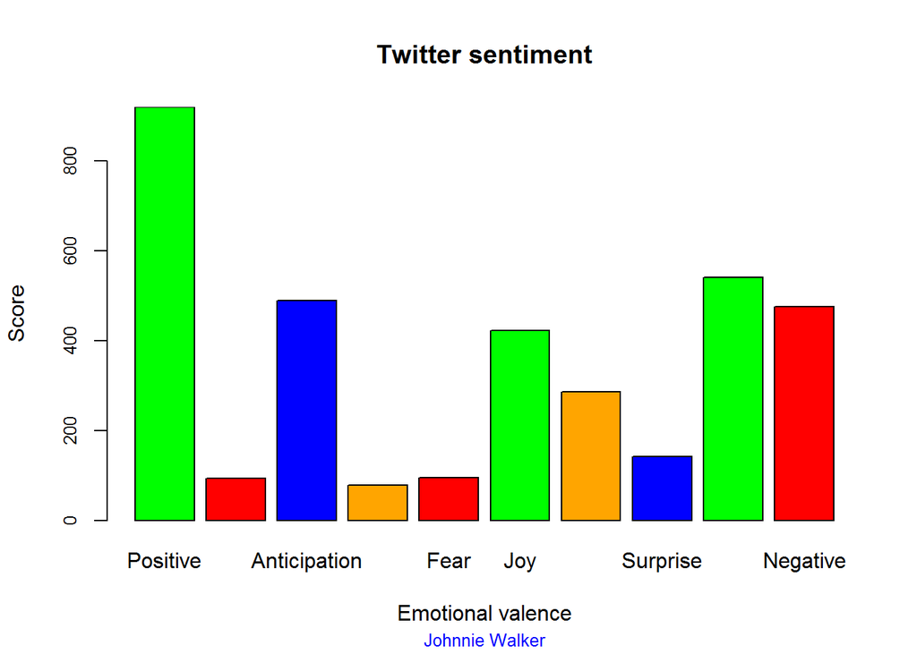

```r
#Sentiment Analysis
#Understand emotional valence in tweets
mysentiment<-get_nrc_sentiment((tweets.df$text))

#Get sentiment score for each emotion
mysentiment.positive =sum(mysentiment$positive)
mysentiment.anger =sum(mysentiment$anger)
mysentiment.anticipation =sum(mysentiment$anticipation)
mysentiment.disgust =sum(mysentiment$disgust)
mysentiment.fear =sum(mysentiment$fear)
mysentiment.joy =sum(mysentiment$joy)
mysentiment.sadness =sum(mysentiment$sadness)
mysentiment.surprise =sum(mysentiment$surprise)
mysentiment.trust =sum(mysentiment$trust)
mysentiment.negative =sum(mysentiment$negative)

#Create the bar chart
yAxis <- c(mysentiment.positive,
           + mysentiment.anger,
           + mysentiment.anticipation,
           + mysentiment.disgust,
           + mysentiment.fear,
           + mysentiment.joy,
           + mysentiment.sadness,
           + mysentiment.surprise,
           + mysentiment.trust,
           + mysentiment.negative)

xAxis <- c("Positive","Anger","Anticipation","Disgust","Fear","Joy","Sadness",
           "Surprise","Trust","Negative")
colors <- c("green","red","blue","orange","red","green","orange","blue","green","red")
yRange <- range(0,yAxis)

#Plot twitter sentiments
barplot(yAxis, names.arg = xAxis,
        xlab = "Emotional valence", ylab = "Score", main = "Twitter sentiment",
        sub = "Johnnie Walker", col = colors, border = "black", xpd = F, ylim = yRange,
        axisnames = T, cex.axis = 0.8, cex.sub = 0.8, col.sub = "blue")
```

Understand polarities by observing movement of sentiment scores for the period in which the tweets are collected (5-May-2019 to 14-May-2019)

```r
#Sentiment Analysis
#Plot by date - understanding cummulative sentiment score movement
mysentimentvalues <- data.frame(get_sentiment((tweets.df$text)))
colnames(mysentimentvalues)<-"polarity"
mysentimentvalues$date <- tweets.df$created
result <- aggregate(polarity ~ date, data = mysentimentvalues, sum)
result
```

```
##          date polarity
## 1  2019-05-05    41.00
## 2  2019-05-06    42.40
## 3  2019-05-07    33.10
## 4  2019-05-08    73.75
## 5  2019-05-09    99.70
## 6  2019-05-10    50.35
## 7  2019-05-11    23.90
## 8  2019-05-12    22.25
## 9  2019-05-13    32.30
## 10 2019-05-14    28.90
```

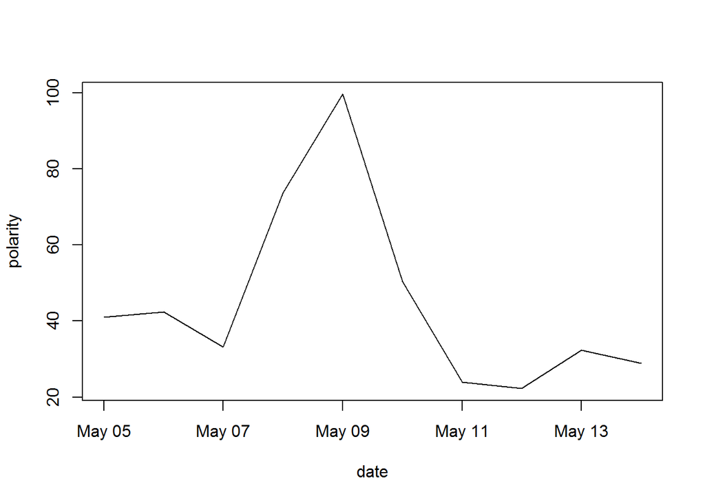

```r
#Plot result
plot(result, type = "l")
```

```r
#Sentiment Analysis
#Plot by date - understanding average sentiment score movement
result1 <- aggregate(polarity ~ date, data = mysentimentvalues, mean)
result1
```

```
##          date  polarity
## 1  2019-05-05 0.5189873
## 2  2019-05-06 0.2753247
## 3  2019-05-07 0.2781513
## 4  2019-05-08 0.4442771
## 5  2019-05-09 0.5219895
## 6  2019-05-10 0.2517500
## 7  2019-05-11 0.2133929
## 8  2019-05-12 0.2816456
## 9  2019-05-13 0.3800000
## 10 2019-05-14 0.2675926
```

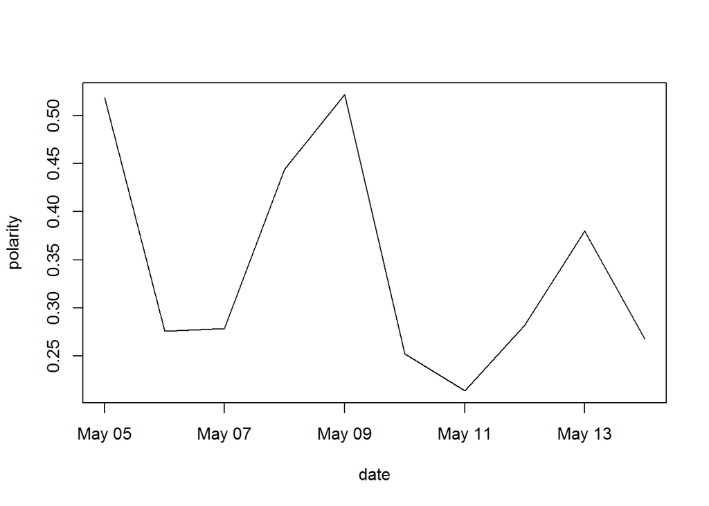

```r
#Plot result
plot(result1, type = "l")
```

When observing the polarity in order to understand the movement of sentiment scores from 5-May-2019 to 14-May-2019, we can see that polarity is very high in the middle around 9th may and somewhat on 13th may.

## Conclusion

Overall Johnnie Walker, as a brand has positive sentiment among people. By analysis we can understand that people have lot of trust on this brand and use it for celebrating at parties when in joyful mood.